# BSL Angle Processing analysis

I’ve only looked at overall averages. In theory it would be possible to correlate by type of rotation e.g. 45deg sign vs 50deg shape rotation, 90deg sign vs 100deg shape rotation but I don’t think there are enough items (only a very short test). I wonder if it is worth reducing the data to just the conditions requiring rotation (ie. 45 & 90 for BSL; 50, 100, 150 for MR). We don’t expect rotation to 0-degree signs, and there is no rotation required for two identical shapes.. So this correlation as is also has lots of non-rotation in the mix

In terms of interpreting the results, I would say that the RT correlation is of far more value than the Accuracy one, since the 3 fluent groups are performing at ceiling accuracy on the BSL task.

BSL task data per subject, 45 & 90 angles only:

```r
BSLAccNo0 <- filter(vpAccPrimes, Angle != "0")
BSLAccNo0 <- BSLAccNo0 %>% group_by(Group, Subject) %>%
  summarize(BSL_ACC = mean(ACC))
print(BSLAccNo0)
```

```
## # A tibble: 45 x 3
## # Groups:   Group [4]
##    Group   Subject BSL_ACC
##    <fct>   <fct>     <dbl>
##  1 L1_Deaf S105      0.942
##  2 L1_Deaf S106      0.936
##  3 L1_Deaf S107      0.977
##  4 L1_Deaf S109      0.953
##  5 L1_Deaf S110      0.936
##  6 L1_Deaf S112      0.919
##  7 L1_Deaf S114      0.977
##  8 L1_Deaf S120      0.965
##  9 L1_Deaf S138      0.936
## 10 L1_Deaf S139      0.959
## # ... with 35 more rows
```

```r
BSLRTNo0 <- filter(vpRTPrimes, Angle != "0", ACC != 0)
BSLRTNo0 <- BSLRTNo0 %>% group_by(Group, Subject) %>%
  summarize(BSL_RT = mean(RT))
print(BSLRTNo0)
```

```
## # A tibble: 45 x 3
## # Groups:   Group [4]
##    Group   Subject BSL_RT
##    <fct>   <fct>    <dbl>
##  1 L1_Deaf S105     1593.
##  2 L1_Deaf S106     1845.
##  3 L1_Deaf S107     1600.
##  4 L1_Deaf S109     1799.
##  5 L1_Deaf S110     1740.
##  6 L1_Deaf S112     1716.
##  7 L1_Deaf S114     1709.
##  8 L1_Deaf S120     1737.
##  9 L1_Deaf S138     1969.
## 10 L1_Deaf S139     1680.
## # ... with 35 more rows
```

MR task data per subject, 50, 100 & 150 rotations only:

```r
mrAccNo0 <- filter(mr, Rotation != "0")
mrAccNo0 <- mrAccNo0 %>% group_by(Group, Subject) %>%
  summarize(MR_ACC = mean(ACC))
print(mrAccNo0)
```

```
## # A tibble: 45 x 3
## # Groups:   Group [4]
##    Group   Subject MR_ACC
##    <fct>   <fct>    <dbl>
##  1 L1_Deaf S105     0.342
##  2 L1_Deaf S106     0.944
##  3 L1_Deaf S107     0.944
##  4 L1_Deaf S109     0.703
##  5 L1_Deaf S110     0.5
##  6 L1_Deaf S112     0.571
##  7 L1_Deaf S114     0.966
##  8 L1_Deaf S120     0.485
##  9 L1_Deaf S138     0.973
## 10 L1_Deaf S139     0.969
## # ... with 35 more rows
```

```r
mrRTNo0 <- filter(mr, Rotation != "0", ACC == 1)
mrRTNo0 <- mrRTNo0 %>% group_by(Group, Subject) %>%
  summarize(MR_RT = mean(RT))
print(mrRTNo0)
```

```
## # A tibble: 45 x 3
## # Groups:   Group [4]
##    Group   Subject MR_RT
##    <fct>   <fct>   <dbl>
##  1 L1_Deaf S105     887.
##  2 L1_Deaf S106    3706.
##  3 L1_Deaf S107    2170.
##  4 L1_Deaf S109    4652.
##  5 L1_Deaf S110    2734
##  6 L1_Deaf S112    3486.
##  7 L1_Deaf S114    5502.
##  8 L1_Deaf S120    3774.
##  9 L1_Deaf S138    4904.
## 10 L1_Deaf S139    2346.
## # ... with 35 more rows
```

Combine tibbles for no 0 data:

```r
AccCorrNo0 <- bind_cols(mrAccNo0, BSLAccNo0)
print(AccCorrNo0)
```

```
## # A tibble: 45 x 6
## # Groups:   Group [4]
##    Group   Subject MR_ACC Group1  Subject1 BSL_ACC
##    <fct>   <fct>    <dbl> <fct>   <fct>      <dbl>
##  1 L1_Deaf S105     0.342 L1_Deaf S105       0.942
##  2 L1_Deaf S106     0.944 L1_Deaf S106       0.936
##  3 L1_Deaf S107     0.944 L1_Deaf S107       0.977
##  4 L1_Deaf S109     0.703 L1_Deaf S109       0.953
##  5 L1_Deaf S110     0.5   L1_Deaf S110       0.936
##  6 L1_Deaf S112     0.571 L1_Deaf S112       0.919
##  7 L1_Deaf S114     0.966 L1_Deaf S114       0.977
##  8 L1_Deaf S120     0.485 L1_Deaf S120       0.965
##  9 L1_Deaf S138     0.973 L1_Deaf S138       0.936
## 10 L1_Deaf S139     0.969 L1_Deaf S139       0.959
## # ... with 35 more rows
```

```r
RTCorrNo0 <- bind_cols(mrRTNo0, BSLRTNo0)
print(RTCorrNo0)
```

```
## # A tibble: 45 x 6
## # Groups:   Group [4]
##    Group   Subject MR_RT Group1  Subject1 BSL_RT
##    <fct>   <fct>   <dbl> <fct>   <fct>     <dbl>
##  1 L1_Deaf S105     887. L1_Deaf S105      1593.
##  2 L1_Deaf S106    3706. L1_Deaf S106      1845.
##  3 L1_Deaf S107    2170. L1_Deaf S107      1600.
##  4 L1_Deaf S109    4652. L1_Deaf S109      1799.
##  5 L1_Deaf S110    2734  L1_Deaf S110      1740.
##  6 L1_Deaf S112    3486. L1_Deaf S112      1716.
##  7 L1_Deaf S114    5502. L1_Deaf S114      1709.
##  8 L1_Deaf S120    3774. L1_Deaf S120      1737.
##  9 L1_Deaf S138    4904. L1_Deaf S138      1969.
## 10 L1_Deaf S139    2346. L1_Deaf S139      1680.
## # ... with 35 more rows
```

Create scatter plots for no 0 data:

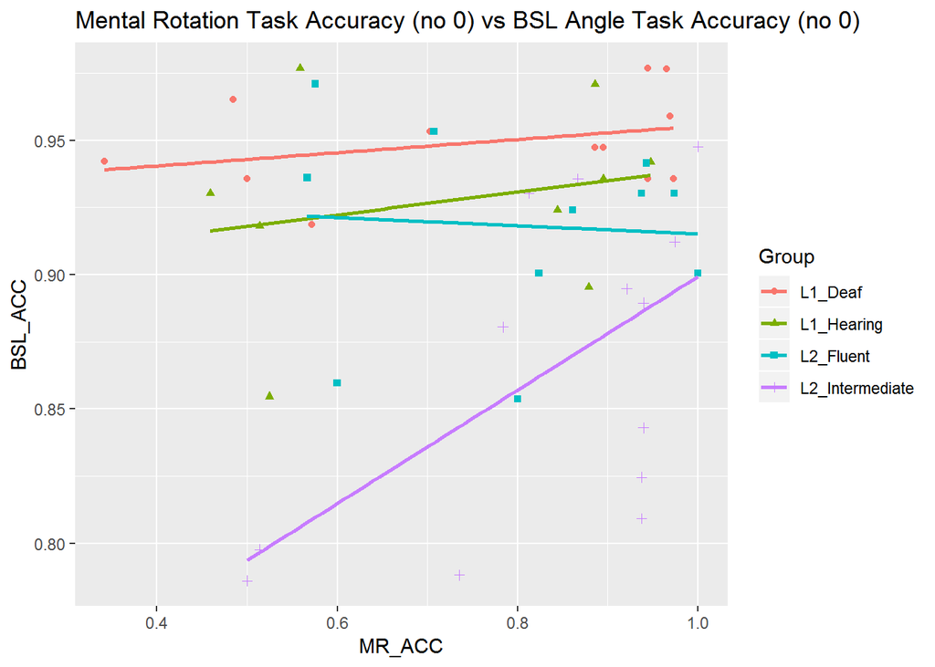

```r
ggplot(AccCorrNo0, aes(x=MR_ACC, y=BSL_ACC, color=Group, shape=Group)) +
  geom_point() +
  geom_smooth(method=lm,se=FALSE) +
  ggtitle('Mental Rotation Task Accuracy (no 0) vs BSL Angle Task Accuracy (no 0)')
```

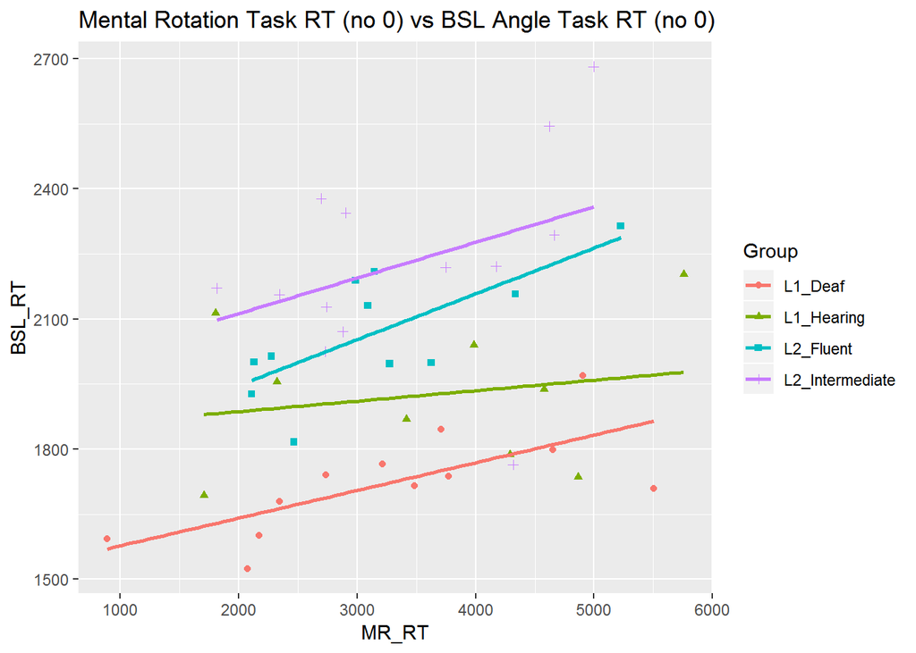

```r
ggplot(RTCorrNo0, aes(x=MR_RT, y=BSL_RT, color=Group, shape=Group)) +
  geom_point() +
  geom_smooth(method=lm,se=FALSE) +
  ggtitle('Mental Rotation Task RT (no 0) vs BSL Angle Task RT (no 0)')
```

Compute no0 correlations between BSL & Mental Rotation tasks:

```r
AccCorrNo0 %>% group_by(Group) %>%
  summarize(AccCORno0=cor(MR_ACC,BSL_ACC))
```

```
## # A tibble: 4 x 2
##   Group           AccCORno0
##   <fct>               <dbl>
## 1 L1_Deaf            0.323
## 2 L1_Hearing         0.230
## 3 L2_Fluent         -0.0674
## 4 L2_Intermediate    0.589
```

```r
RTCorrNo0 %>% group_by(Group) %>%
  summarize(RTCORno0=cor(MR_RT,BSL_RT))
```

```
## # A tibble: 4 x 2
##   Group           RTCORno0
##   <fct>              <dbl>
## 1 L1_Deaf            0.712
## 2 L1_Hearing         0.199
## 3 L2_Fluent          0.708
## 4 L2_Intermediate    0.365
```